# Practice 7

Guglielmo Bonifazi, Emanuele Sorgente

27/11/2021

Exercise 1

```r
true_f =function(x) {3*sin(x) + x}
n=20
set.seed(7)
x0=sort(runif(n=n,0,10))
```

Generating the errors:

```r
set.seed(7)
epsilons=rnorm(n=20)
y0=true_f(x0)+epsilons
```

```r
library(tree)
model0=tree(y0~x0)
```

3. Plotting the true function:

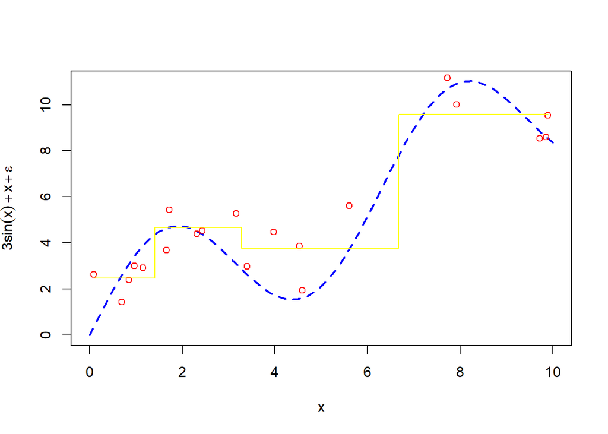

```r
x11()
curve(true_f(x),main="", xlab = "x", ylab = expression(3*sin(x)+x+epsilon),      type = "l", lty = 2, lwd = 2, col = "blue",from=0,to=10)
#The observed data
points(x0,y0,col='red')
#The tree model
partition.tree(tree=model0,add=T,col='yellow')
```

(d)&(e)

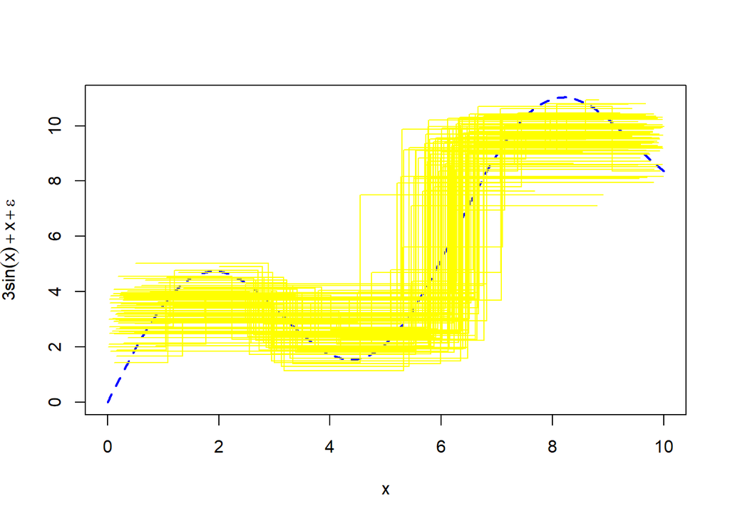

```r
curve(true_f(x),main="", xlab = "x", ylab = expression(3*sin(x)+x+epsilon),
      type = "l", lty = 2, lwd = 2, col = "blue",from=0,to=10)
for (i in 1:100){
  x=sort(runif(n=n,0,10))
  epsilons=rnorm(n=20)
  y=true_f(x)+epsilons
  model=tree(y~x)
  partition.tree(tree=model,add=T,col='yellow')
  }
```

6. From the graphical visualization it emerges clearly that CART have a low BIAS, indeed we can observe that in mean the models are centered to the true function. On the contrary it has a high Variance. The solution to this problem is quite straight: we can take the average of the prediction of different models. For the Central Limit theorem we will obtain a model which is still centered approximately to the ground truth, but at the same time it will have a lower variance (the higher the number of models the higher will be the reduction: V[ensemble]=V[tree]/n)
7. Of course, in real cases we do not know the real distribution that has generated the sample observed. So we can not create indipendent models samplig from the distribution different inputs. Nonetheless we can estimate it through a re-sampling technique. Those kind of procedures are usually called bootstrap. Basically, we can generate a ‘new’ sample by sampling with repetition the observed one. This can generate a huge number of samples, and it would be not feasible to train a model for each of them. Nonetheless, we can simply randomly choose only some of them (a number we suppose is sufficient). Doubtless, the higher the number of bootstrap sample, the bigger, will be the number of tree used, and so the higher the reduction of the variance. Besides to decrease the correlation between the tree (for instance CLT is valid only with Indipindent variables) we can include some randomness in the algorithm, for example randomly selecting only some of the attributes that will be used by each tree. Combining these two procedures we will end up with a Random Forest.

```r
library(randomForest)
```

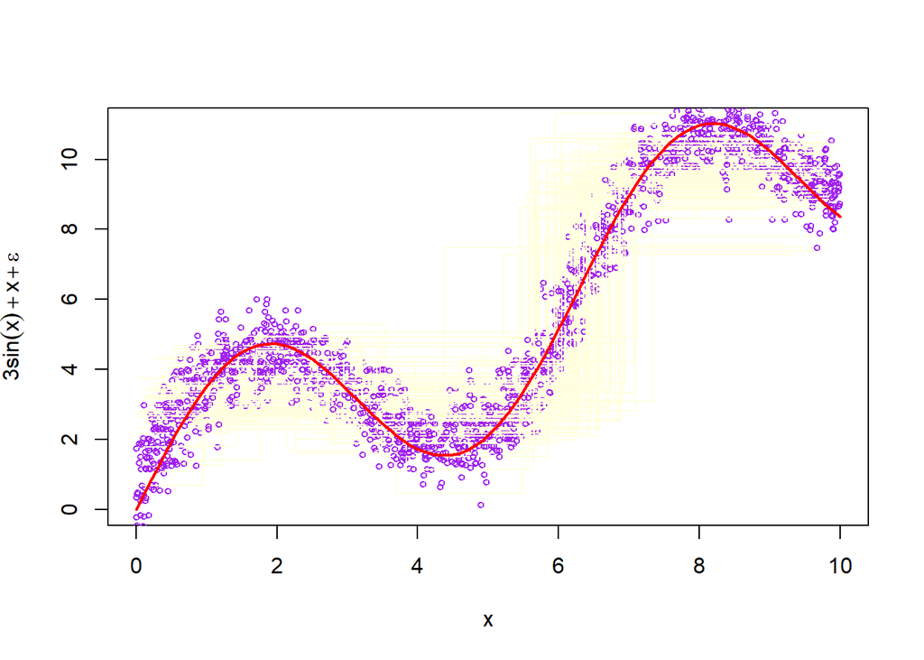

```r
curve(true_f(x),main="", xlab = "x", ylab = expression(3*sin(x)+x+epsilon),
      type = "l", lty = 2, lwd = 1, col = "black",from=0,to=10)
for (i in 1:100){
  x=sort(runif(n=n,0,10))
  epsilons=rnorm(n=20)
  y=true_f(x)+epsilons
  tr=tree(y~x)
  rf=randomForest(y~x,mtry=1,ntree=100)
  y_rf=predict(rf,x)
  partition.tree(tree=tr,add=T,col='lightyellow')
  points(x,y_rf,col='purple',cex=0.6)
}
curve(true_f(x),main="", xlab = "x", ylab = expression(3*sin(x)+x+epsilon),
      type = "l", lty = 1, lwd = 2, col = "red",from=0,to=10,add=TRUE)
```

As we can see, the model is smoother and follow more accurately the true function (it has a lower variance).

Exercise 2

```r
data=read.csv(file.choose())
data$output=as.factor(data$output)
```

HPO:

```r
library(caret)
```

Manual extension of the caret function for the random forest algorithm.

```r
customRF= list(type = "Classification", library = "randomForest", loop = NULL)
customRF$parameters = data.frame(parameter = c("mtry", "ntree",'max_nodes'), class = rep("numeric", 3), label = c("mtry", "ntree",'max_nodes'))
customRF$grid = function(x, y, len = NULL, search = "grid") {}
customRF$fit = function(x, y, wts, param, lev, last, weights, classProbs, ...) {
  randomForest(x, y, mtry = param$mtry, ntree=param$ntree, ...)
}
customRF$predict = function(modelFit, newdata, preProc = NULL, submodels = NULL)
  predict(modelFit, newdata)
customRF$prob = function(modelFit, newdata, preProc = NULL, submodels = NULL)
  predict(modelFit, newdata, type = "prob")
customRF$sort = function(x) x[order(x[,1]),]
customRF$levels = function(x) x$classes
```

Training of the model:

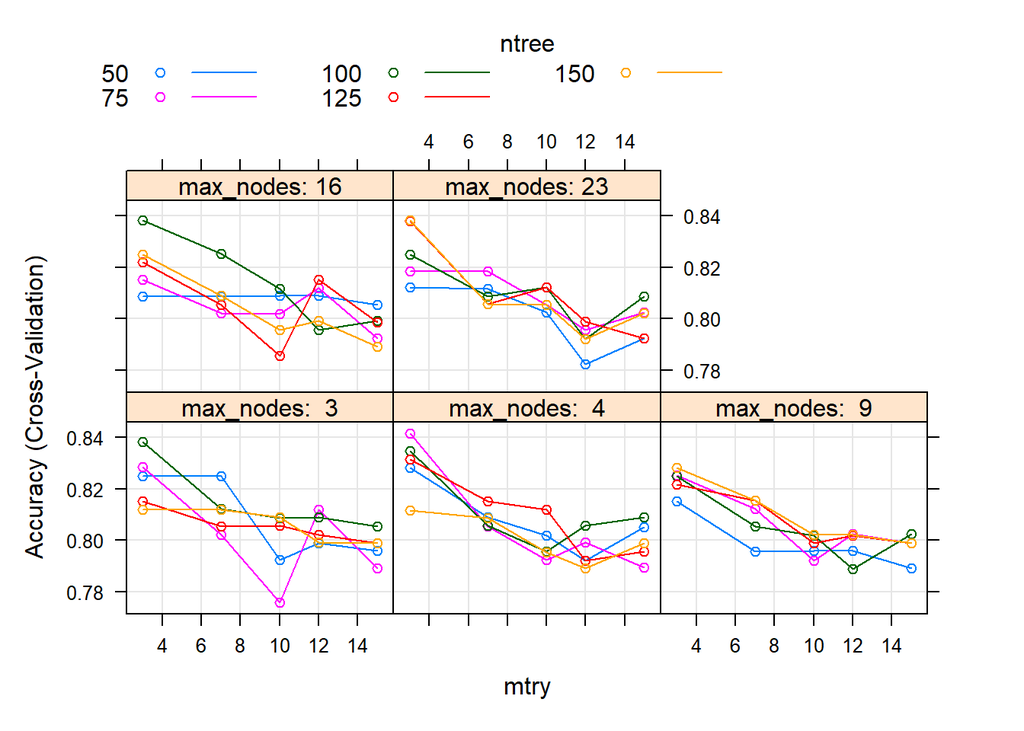

```r
control = trainControl(method="cv", number=10)
set.seed(7)
tunegrid = expand.grid(.mtry=sample(1:15,5,replace=T), .ntree=c(50,75,100,125,150),.max_nodes=sample(2:24,5,replace=T))
options(warn=-1)
custom= train(output~., data=data, method=customRF, metric='Accuracy', tuneGrid=tunegrid, trControl=control)
options(warn=0)
plot(custom)
```

```r
custom$bestTune
```

```
##   mtry ntree max_nodes
## 7    3    75         4
```

Here we can visualize what are the the best values selected by the randomized search. This is our best model, trained with the parameters selected through HPO.

```r
best_model=randomForest(output~., data=data, ntree=75,max_nodes=4,mtry=3)
```

1. Analysis of the performances with mtry:

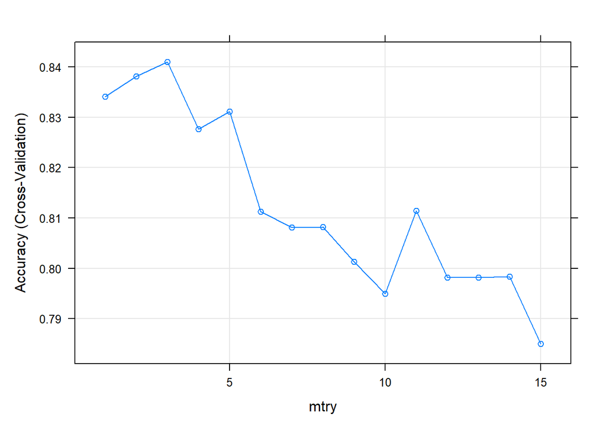

```r
set.seed(50)
tunegrid = expand.grid(.mtry=c(1:15), .ntree=75,.max_nodes=4)
options(warn=-1)
custom= train(output~., data=data, method=customRF, metric='Accuracy', tuneGrid=tunegrid, trControl=control)
options(warn=0)
plot(custom)
```

```r
custom$bestTune
```

```
##   mtry ntree max_nodes
## 3    3    75         4
```

We can see that,after an initial improvement, as the number of features considered for each split increases, the accuracy of the model decline. This is logical, indeed as the number of randomly selected variables approach the total number of predictors the n_tree produced trees will be more correlated, therefore the reduction of the variance caused by the average of the predictions is going to be less effective. In this case, the optimal value stands at 3, which is close to p/3, the number suggested by heuristics.

2. Analysis of the Number of trees:

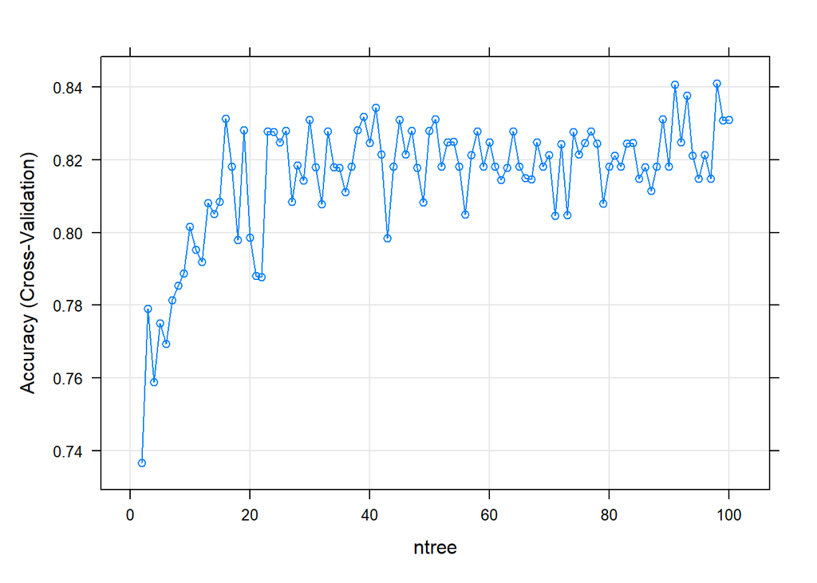

```r
set.seed(50)
tunegrid = expand.grid(.mtry=3, .ntree=2:100,.max_nodes=4)
options(warn=-1)
custom= train(output~., data=data, method=customRF, metric='Accuracy', tuneGrid=tunegrid, trControl=control)
options(warn=0)
plot(custom)
```

3. Analysis of the depth of the trees:

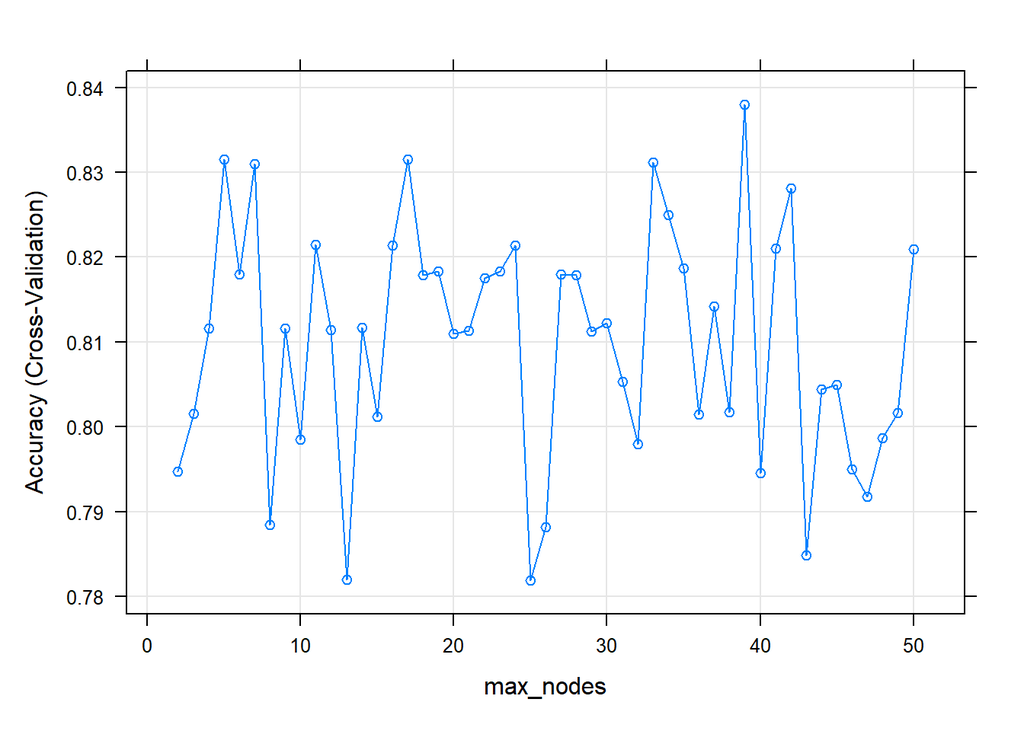

```r
set.seed(50)
tunegrid = expand.grid(.mtry=3, .ntree=20,.max_nodes=2:50)
options(warn=-1)
custom= train(output~., data=data, method=customRF, metric='Accuracy', tuneGrid=tunegrid, trControl=control)
options(warn=0)
plot(custom)
```

No significant pattern seems to emerge. Moreover the accuracy does not change significantly with diverse values of the attribute. As a consequence, we can conclude that it is not relevant

Thanks to the findings we can consider the final model

```r
set.seed(78)
best_model=randomForest(output~., data=data, ntree=20,max_nodes=4,mtry=3,importance=T)
```

```r
set.seed(957)
imp1=sort(importance(best_model,type=1),index=T,decreasing = T)
imp2=sort(importance(best_model,type=2),index=T,decreasing = T)
imp=cbind(colnames(data)[imp1$ix],imp1$x,colnames(data)[imp2$ix],imp2$x)
colnames(imp)=c('Ranking 1','Score 1','Ranking 2','Score 2')
imp
```

```
##       Ranking 1  Score 1              Ranking 2  Score 2
##  [1,] "caa"      "7.29718059450413"   "cp"       "21.3401929432312"
##  [2,] "oldpeak"  "5.76020962754589"   "thalachh" "15.8976702019478"
##  [3,] "cp"       "4.69354663596434"   "thall"    "15.3468009744851"
##  [4,] "thall"    "3.76948945182755"   "oldpeak"  "15.2056510271658"
##  [5,] "sex"      "2.19608137093059"   "caa"      "13.824287183149"
##  [6,] "age"      "1.8569600602528"    "exng"     "11.3944282920674"
##  [7,] "thalachh" "1.71963173960399"   "slp"      "11.3367366198756"
##  [8,] "slp"      "0.972171858407691"  "age"      "11.2853142163303"
##  [9,] "exng"     "0.956091894646527"  "trtbps"   "10.5592384414142"
## [10,] "fbs"      "0.412852235857262"  "chol"     "10.1452622050588"
## [11,] "trtbps"   "-0.531865336885727" "sex"      "6.38512592949209"
## [12,] "restecg"  "-0.61637453367184"  "restecg"  "2.81159233036796"
## [13,] "chol"     "-1.93986659046426"  "fbs"      "1.8509511858445"
```

We can extract some relevant conclusions comparing the two measurement of feature importance.

Previous peak, caa, chest pain type and thall occupy the first four positions for the first criterium and the first five with the second one. This convergence clearly indicate their importance. Besides,looking at the worst scores, a useful analogy occurs. Cholestoral in mg/dl,Resting electrocardiographic results,trtbs and Fasting blood sugar are present in the last four and in the last five places of the rankings. We can conclude that there is quite a good concordance between the two outputs. The only big difference deals with the variable sex, which stands at the 5th and at the 11th position.

Another important aspect to be taken into account is the recording of three negative scores for the first method. This is the difference between the error of a model trained with the actual data and the error of a model trained with the same data but with values of the considered variable permuted. As a consequence, in this case random values of Cholestoral in mg/dl,Resting electrocardiographic results,trtbs, have lead to better results than the real ones. Thus, there is strong evidence toclaim that those features are not significant for our model (moreover, they have been poorly evaluated even by the mean decreased Gini index in node).

```r
library(gbm)
```

It is hard to know what is the optimal number of variables to keep. Indeed, from the curse of dimensionality we know that the larger is the quantity of features the higher is the number of instances needed by the model to generalize well. Besides, redundant information or useless variables can negatively interact with the training.

```r
data=data[,-c(4,5,6)]
```

Now we are going to tune the following hyperparameters: The number of trees, the learning rate and the depth of the basic models.

```r
set.seed(13344)
gbmGrid = expand.grid( n.trees = seq(1,100,10),
                        shrinkage = seq(0,0.9,length.out=20),
                       interaction.depth=1:4, n.minobsinnode=10)
```

The value of the minimal number of observations in a leaf as well control the depth of the trees, but we are not considering it in the tuning

```r
gradient_boost= train(output~., data=data, method='gbm', metric='Accuracy', trControl=control,verbose=0,tuneGrid=gbmGrid)
gradient_boost$bestTune
```

```
##     n.trees interaction.depth shrinkage n.minobsinnode
## 173      21                 2 0.1894737             10
```

Now the relationship between the performances of the model and the parameters learning rate and number of trees will be analyzed.

```r
set.seed(13344)
gbmGrid = expand.grid( n.trees = c(1:7,seq(8,50,length.out=28)),
                       shrinkage = seq(0,1,length.out=35),
                       interaction.depth=2, n.minobsinnode=10)
gradient_boost= train(output~., data=data, method='gbm', metric='Accuracy', trControl=control,verbose=0,tuneGrid=gbmGrid)
```

Small number of trees

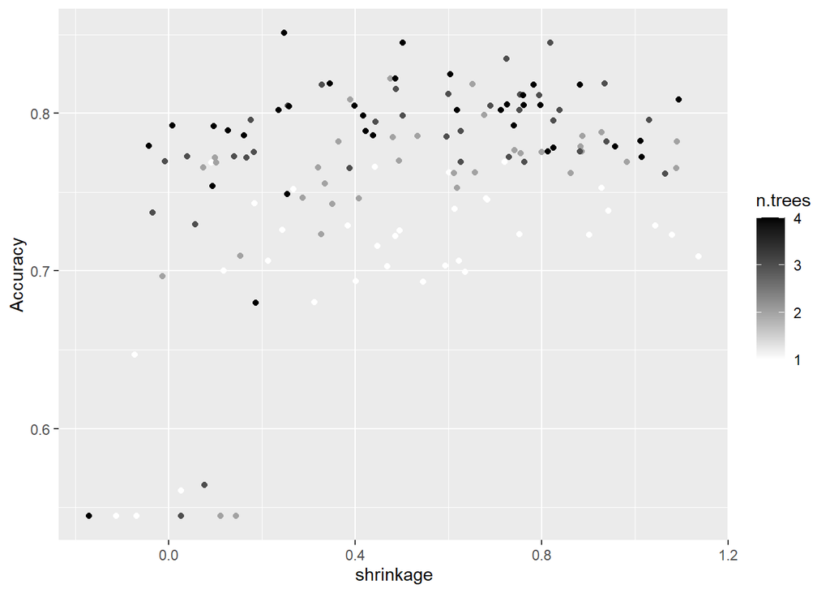

```r
library(ggplot2)
x11()
ggplot(gradient_boost$results[gradient_boost$results$n.trees<5,], aes(x = shrinkage, y = Accuracy, color = n.trees)) +
  geom_jitter(width = .2)+scale_colour_gradient(low = "white", high = "black")
```

We can observe that with a small number of trees there is a positive relationship between Accuracy and learning rate. Indeed, as there are few iterations, a smaller number of corrections of the errors will occur. As a consequence giving them more weight will effectively lead to a reduction of the residuals, and not to overfit.

Medium-low number of trees:

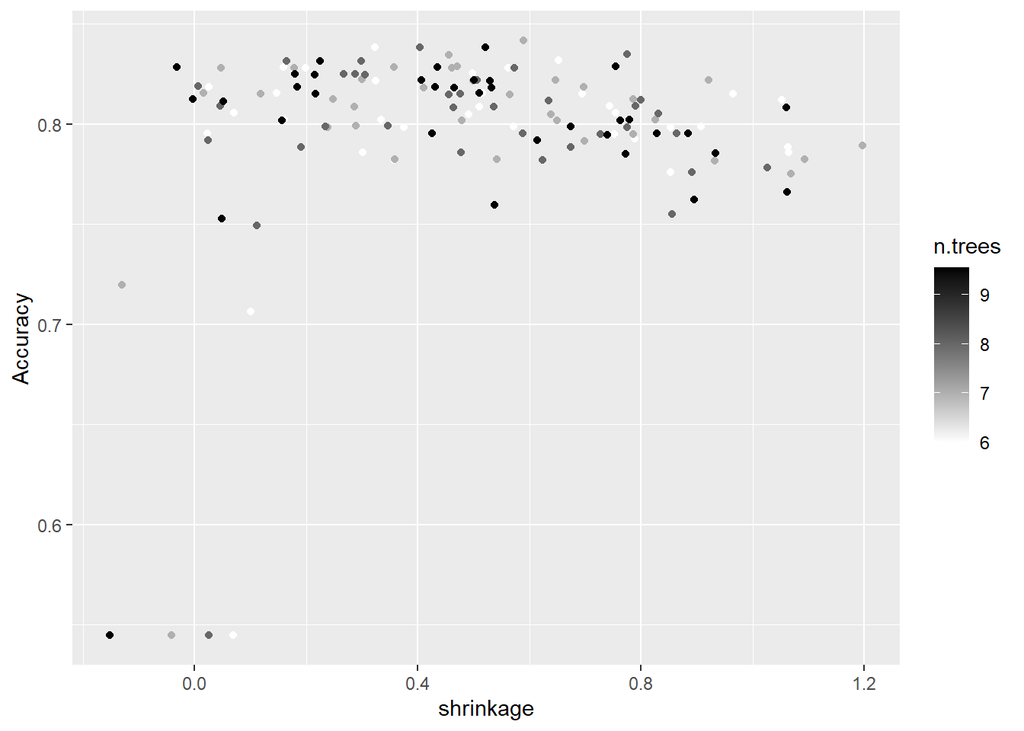

```r
ggplot(gradient_boost$results[gradient_boost$results$n.trees>5 & gradient_boost$results$n.trees<10,], aes(x = shrinkage, y = Accuracy, color = n.trees)) +
  geom_jitter(width = .2)+scale_colour_gradient(low = "white", high = "black")
```

In this case a concave trend emerge. The Accuracy increases until we reach a threshold (approximately at a shrinkage value between 0.5 and 0.6). A greater learning rate will make the model take into account even the noise of the instances in order to correct the predictions, resulting in a worse ability to generalize and in poorer performances.

Medium high number of trees:

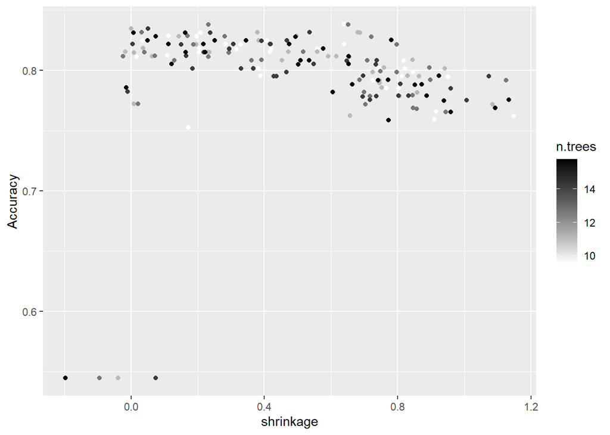

```r
ggplot(gradient_boost$results[gradient_boost$results$n.trees>9 & gradient_boost$results$n.trees<16,], aes(x = shrinkage, y = Accuracy, color = n.trees)) +
  geom_jitter(width = .2)+scale_colour_gradient(low = "white", high = "black")
```

The same concave pattern is found here, but as obvious, a smaller learning rate is needed to avoid overfitting, as the number of trees is higher.

High number of trees:

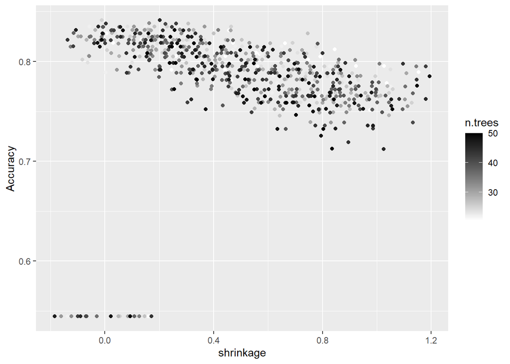

```r
ggplot(gradient_boost$results[gradient_boost$results$n.trees>20,], aes(x = shrinkage, y = Accuracy, color = n.trees)) +
  geom_jitter(width = .2)+scale_colour_gradient(low = "white", high = "black")
```

In this case the relationship is almost completely negative. Indeed, given the amount of tree, a very small value learning rate is required by the model not to overfit.

The results are aligned with what would have expected from the theory.

Partially dependency plot:

```r
library(pdp)
```

It shows the dependency between a variable and the outcome. In particular, calculating for each value of x the outcome of y considering every observed value of the other variables and then taking the average. Of course the plot is reliable only if the features are uncorrelated, as otherwise, for a given value of the considered variable, the other variables will assume only some of their possible values, and with different probabilities.

NOTE: I have tried to produce the plots in the same window but given that they are lattice plots, the conventional par function does not work.

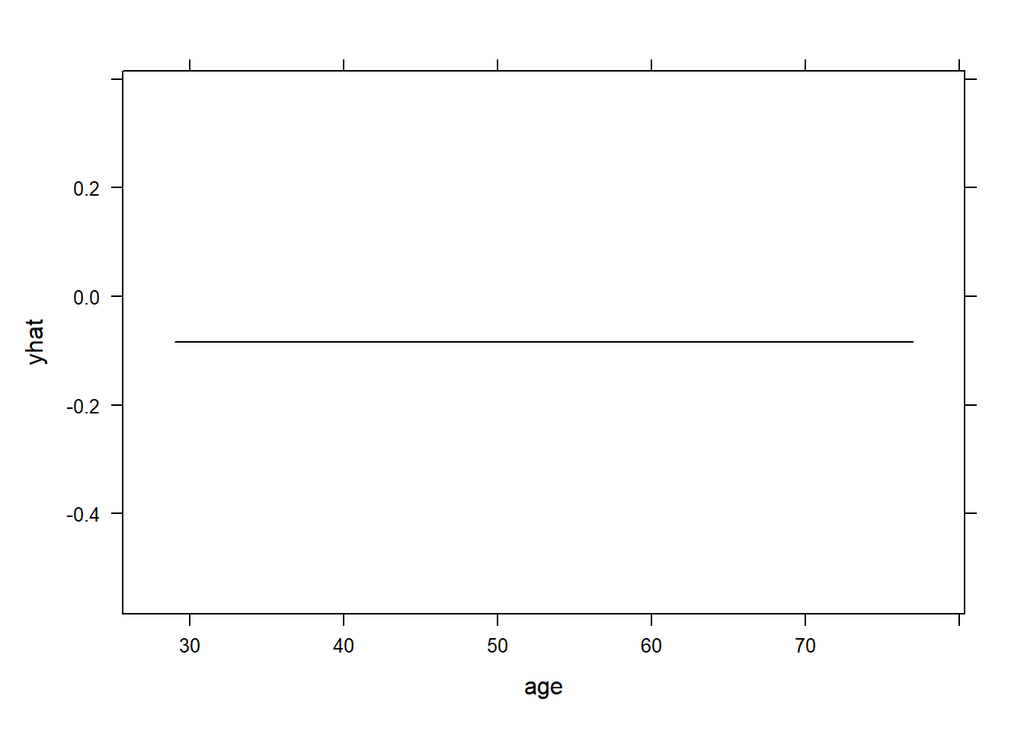

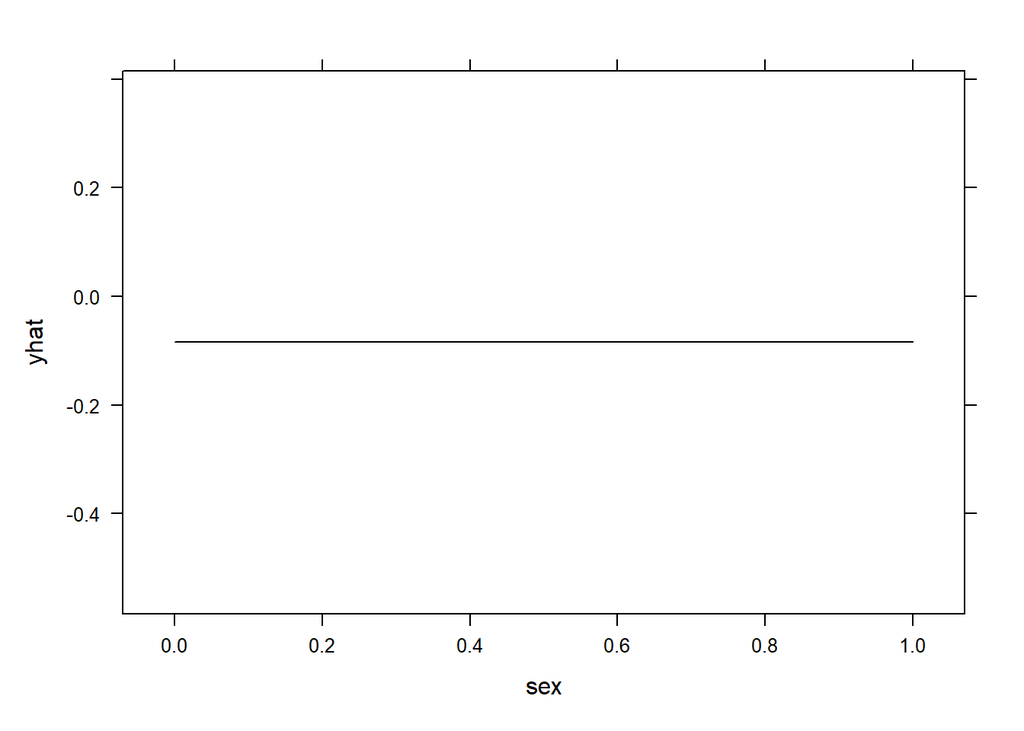

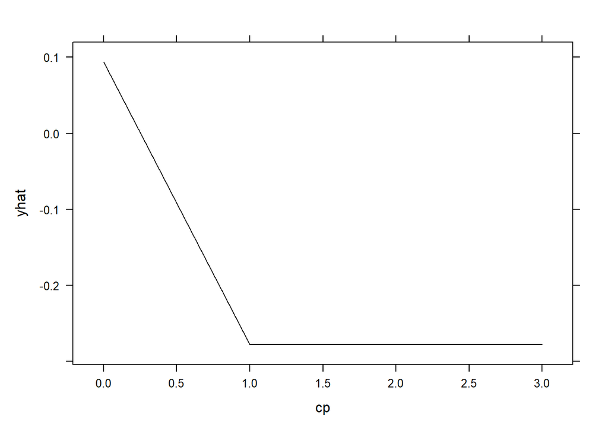

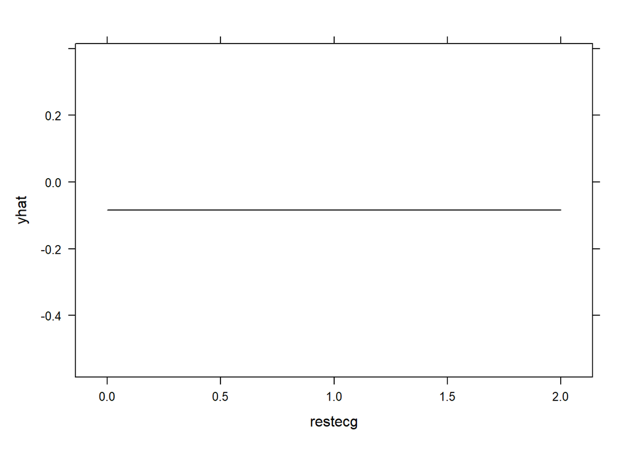

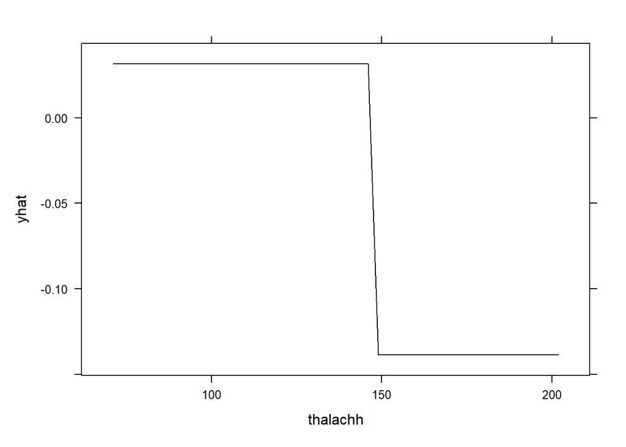

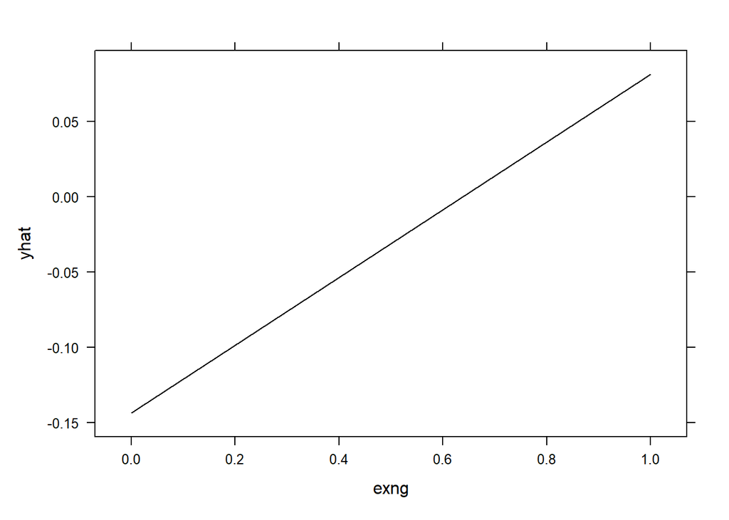

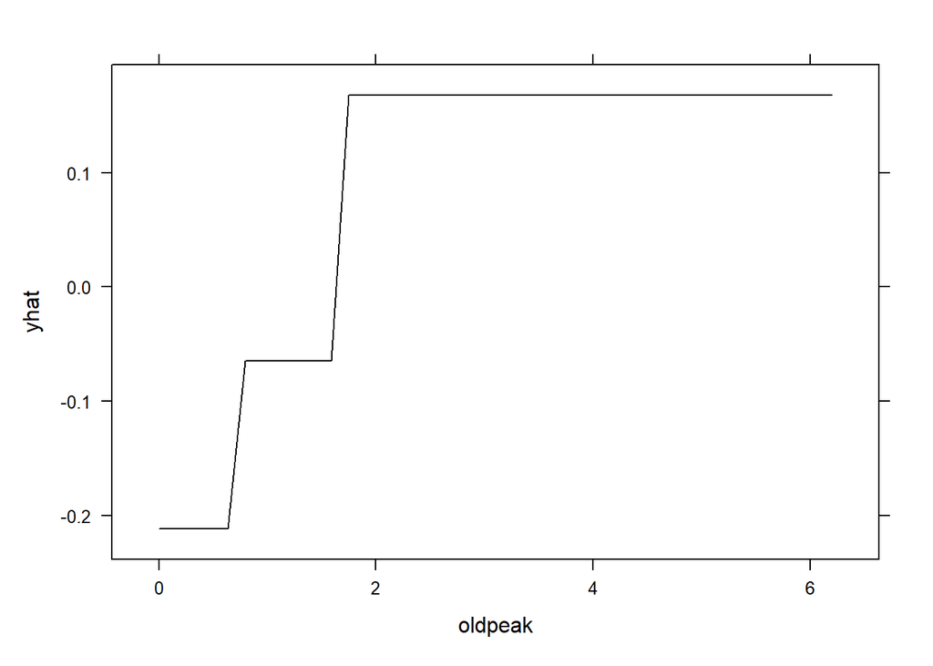

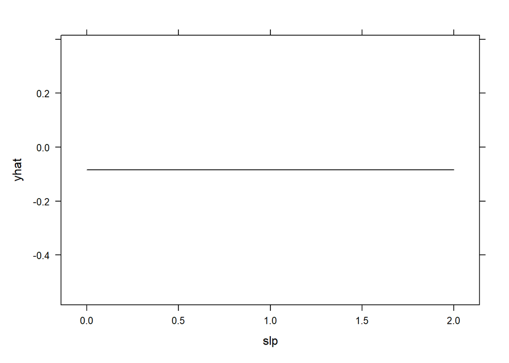

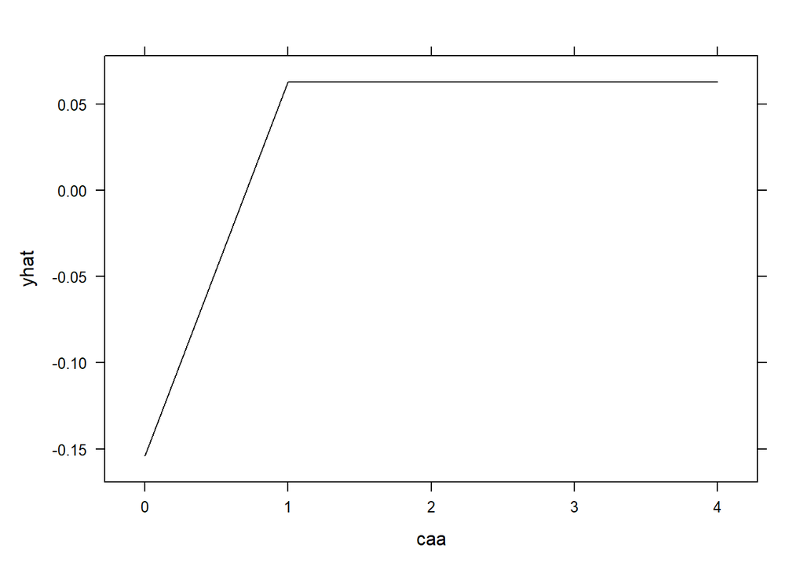

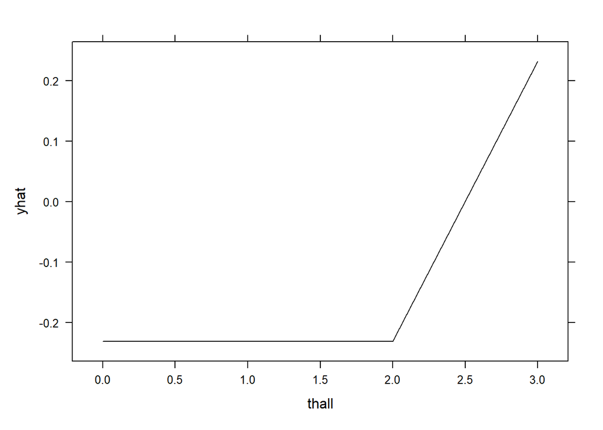

```r
for(var in colnames(data)[-11]){
  p=partial(gradient_boost,pred.var=var)
  g=plotPartial(p,plot.pdp = TRUE)
  print(g)
}
```